# Foundations of Data Science Project - Diabetes Analysis

## Context

Diabetes is one of the most frequent diseases worldwide and the number of diabetic patients are growing over the years. The main cause of diabetes remains unknown, yet scientists believe that both genetic factors and environmental lifestyle play a major role in diabetes.

A few years ago research was done on a tribe in America which is called the Pima tribe (also known as the Pima Indians). In this tribe, it was found that the ladies are prone to diabetes very early. Several constraints were placed on the selection of these instances from a larger database. In particular, all patients were females at least 21 years old of Pima Indian heritage.

## Objective

Here, we are analyzing different aspects of Diabetes in the Pima Indians tribe by doing Exploratory Data Analysis.

## Data Dictionary

The dataset has the following information:

- Pregnancies: Number of times pregnant
- Glucose: Plasma glucose concentration over 2 hours in an oral glucose tolerance test
- BloodPressure: Diastolic blood pressure (mm Hg)
- SkinThickness: Triceps skin fold thickness (mm)
- Insulin: 2-Hour serum insulin (mu U/ml)
- BMI: Body mass index (weight in kg/(height in m)^2)
- DiabetesPedigreeFunction: A function which scores likelihood of diabetes based on family history.
- Age: Age in years
- Outcome : Class variable (0: person is not diabetic or 1: person is diabetic)

## Q 1: Import the necessary libraries and briefly explain the use of each library (3 Marks)

```python
#remove _____ & write the appropriate library name

import numpy as np
import pandas as pd

import seaborn as sns
import matplotlib.pyplot as plt
%matplotlib inline
```

#### Write your Answer here:

Ans 1: numpy is short form for Numerical Python and is one of the core libraries for scientific computing. Once imported, we can use numpy functions for all calculations. Create multi dimentional arrays etc.

## Q 2: Read the given dataset (1 Mark)

```python
#remove _____ & write the appropriate function name

pima = pd.read_csv("diabetes.csv")
pima.tail() #verify if the file is loaded
```

|  | Pregnancies | Glucose | BloodPressure | SkinThickness | Insulin | BMI | DiabetesPedigreeFunction | Age | Outcome |
| --- | --- | --- | --- | --- | --- | --- | --- | --- | --- |
| 763 | 10 | 101 | 76 | 48 | 180 | 32.9 | 0.171 | 63 | 0 |
| 764 | 2 | 122 | 70 | 27 | 0 | 36.8 | 0.340 | 27 | 0 |
| 765 | 5 | 121 | 72 | 23 | 112 | 26.2 | 0.245 | 30 | 0 |
| 766 | 1 | 126 | 60 | 0 | 0 | 30.1 | 0.349 | 47 | 1 |
| 767 | 1 | 93 | 70 | 31 | 0 | 30.4 | 0.315 | 23 | 0 |

## Q3. Show the last 10 records of the dataset. How many columns are there? (1 Mark)

```python
#remove ______ and write the appropriate number in the function

pima.tail(10)
```

|  | Pregnancies | Glucose | BloodPressure | SkinThickness | Insulin | BMI | DiabetesPedigreeFunction | Age | Outcome |
| --- | --- | --- | --- | --- | --- | --- | --- | --- | --- |
| 758 | 1 | 106 | 76 | 0 | 0 | 37.5 | 0.197 | 26 | 0 |
| 759 | 6 | 190 | 92 | 0 | 0 | 35.5 | 0.278 | 66 | 1 |
| 760 | 2 | 88 | 58 | 26 | 16 | 28.4 | 0.766 | 22 | 0 |
| 761 | 9 | 170 | 74 | 31 | 0 | 44.0 | 0.403 | 43 | 1 |
| 762 | 9 | 89 | 62 | 0 | 0 | 22.5 | 0.142 | 33 | 0 |
| 763 | 10 | 101 | 76 | 48 | 180 | 32.9 | 0.171 | 63 | 0 |
| 764 | 2 | 122 | 70 | 27 | 0 | 36.8 | 0.340 | 27 | 0 |
| 765 | 5 | 121 | 72 | 23 | 112 | 26.2 | 0.245 | 30 | 0 |
| 766 | 1 | 126 | 60 | 0 | 0 | 30.1 | 0.349 | 47 | 1 |
| 767 | 1 | 93 | 70 | 31 | 0 | 30.4 | 0.315 | 23 | 0 |

#### Write your Answer here:

Ans 3:tail fuction takes integer input, so just pass n to see last n rows, here n=10.

## Q4. Show the first 10 records of the dataset (1 Mark)

```python
#remove _____ & write the appropriate function name and the number of rows to get in the output

pima.head(10)
```

|  | Pregnancies | Glucose | BloodPressure | SkinThickness | Insulin | BMI | DiabetesPedigreeFunction | Age | Outcome |
| --- | --- | --- | --- | --- | --- | --- | --- | --- | --- |
| 0 | 6 | 148 | 72 | 35 | 0 | 33.6 | 0.627 | 50 | 1 |
| 1 | 1 | 85 | 66 | 29 | 0 | 26.6 | 0.351 | 31 | 0 |
| 2 | 8 | 183 | 64 | 0 | 0 | 23.3 | 0.672 | 32 | 1 |
| 3 | 1 | 89 | 66 | 23 | 94 | 28.1 | 0.167 | 21 | 0 |
| 4 | 0 | 137 | 40 | 35 | 168 | 43.1 | 2.288 | 33 | 1 |
| 5 | 5 | 116 | 74 | 0 | 0 | 25.6 | 0.201 | 30 | 0 |
| 6 | 3 | 78 | 50 | 32 | 88 | 31.0 | 0.248 | 26 | 1 |
| 7 | 10 | 115 | 0 | 0 | 0 | 35.3 | 0.134 | 29 | 0 |
| 8 | 2 | 197 | 70 | 45 | 543 | 30.5 | 0.158 | 53 | 1 |
| 9 | 8 | 125 | 96 | 0 | 0 | 0.0 | 0.232 | 54 | 1 |

Ans 4: same as tail, head fuction takes integer input, so just pass n to see first n rows, here n=10.

## Q5. What do you understand by the dimension of the dataset? Find the dimension of the `pima` dataframe. (1 Mark)

```python
#remove _____ & write the appropriate function name

pima.shape
```

```
(768, 9)
```

#### Write your Answer here:

Ans 5: shape is an attribute of dataframe that returns a tuple with number of rows and columns of the dataframe (rows, columns). Remember table header / variable name row is not included in the return value when shape is called. And index column is not included as well.

## Q6. What do you understand by the size of the dataset? Find the size of the `pima` dataframe. (1 Mark)

```python
#remove _____ & write the appropriate function name

pima.size
```

```
6912
```

#### Write your Answer here:

Ans 6: size is an attribute of data frame that returns total number of elements in the data frame / object. As this is the count of number of elements return type is always an integer.

## Q7. What are the data types of all the variables in the data set? (2 Marks)

**Hint: Use info() function to get all the information about the dataset.**

```python
#remove _____ & write the appropriate function name

pima.info()
```

```
<class 'pandas.core.frame.DataFrame'>
RangeIndex: 768 entries, 0 to 767
Data columns (total 9 columns):
 #   Column                    Non-Null Count  Dtype
---  ------                    --------------  -----
 0   Pregnancies               768 non-null    int64
 1   Glucose                   768 non-null    int64
 2   BloodPressure             768 non-null    int64
 3   SkinThickness             768 non-null    int64
 4   Insulin                   768 non-null    int64
 5   BMI                       768 non-null    float64
 6   DiabetesPedigreeFunction  768 non-null    float64
 7   Age                       768 non-null    int64
 8   Outcome                   768 non-null    int64
dtypes: float64(2), int64(7)
memory usage: 54.1 KB
```

#### Write your Answer here:

Ans 7: The python native data types in the data set are int and float. pima.dtypes can also be used to get this information. The 64 in the data type represents the number of bits used to store the values, so we can say that pandas data types in the given data set are int64 and float64.

## Q8. What do you mean by missing values? Are there any missing values in the `pima` dataframe? (2 Marks)

```python
#remove _____ & write the appropriate function name

pima.isna().values.any()
```

```
False
```

#### Write your Answer here:

Ans 8: Missing values in dataframe indicates a cell value containing None or NaN values. isna/isnull can be used to find the missing values which will return a boolean value True if missing values found and False otherwise. Note that empty strings like '' are not considered as missing values.

## Q9. What does summary statistics of data represents? Find the summary statistics for all variables except 'Outcome' in the `pima` data? Take one column/variable from the output table and explain all the statistical measures. (3 Marks)

```python
#remove _____ & write the appropriate function name
pima_stats=pima.iloc[:,0:8].describe()
pima_stats.loc["median"]=pima.iloc[:,0:8].median()
display(pima_stats)
#pima.iloc[:,0:8].median() to calulate median when it makes sense.
#pima.iloc[:,0:8].mean() to calulate mean
#pima.iloc[:,0:8].mode() to calulate mean when it makes sense.
#pima.iloc[:,0:8].min() to get lowest value from each column
#pima.iloc[:,0:8].max() to get highest value from each column
#pima.iloc[:,0:8].std() to calculate the standard deviation.
display(pima_stats.iloc[:,1:2]) # to print only Glucose
display(pima.sort_values(by=["Glucose"]).head(1).iloc[:,1:2]) #sort by Glucose in ascending and print head to see min values
pima.sort_values(by=["Glucose"]).tail(1).iloc[:,1:2] #sort by Glucose in ascending and print tail to see min values
```

|  | Pregnancies | Glucose | BloodPressure | SkinThickness | Insulin | BMI | DiabetesPedigreeFunction | Age |
| --- | --- | --- | --- | --- | --- | --- | --- | --- |
| count | 768.000000 | 768.000000 | 768.000000 | 768.000000 | 768.000000 | 768.000000 | 768.000000 | 768.000000 |
| mean | 3.845052 | 120.894531 | 69.105469 | 20.536458 | 79.799479 | 31.992578 | 0.471876 | 33.240885 |
| std | 3.369578 | 31.972618 | 19.355807 | 15.952218 | 115.244002 | 7.884160 | 0.331329 | 11.760232 |
| min | 0.000000 | 0.000000 | 0.000000 | 0.000000 | 0.000000 | 0.000000 | 0.078000 | 21.000000 |
| 25% | 1.000000 | 99.000000 | 62.000000 | 0.000000 | 0.000000 | 27.300000 | 0.243750 | 24.000000 |
| 50% | 3.000000 | 117.000000 | 72.000000 | 23.000000 | 30.500000 | 32.000000 | 0.372500 | 29.000000 |
| 75% | 6.000000 | 140.250000 | 80.000000 | 32.000000 | 127.250000 | 36.600000 | 0.626250 | 41.000000 |
| max | 17.000000 | 199.000000 | 122.000000 | 99.000000 | 846.000000 | 67.100000 | 2.420000 | 81.000000 |
| median | 3.000000 | 117.000000 | 72.000000 | 23.000000 | 30.500000 | 32.000000 | 0.372500 | 29.000000 |

|  | Glucose |
| --- | --- |
| count | 768.000000 |
| mean | 120.894531 |
| std | 31.972618 |
| min | 0.000000 |
| 25% | 99.000000 |
| 50% | 117.000000 |
| 75% | 140.250000 |
| max | 199.000000 |
| median | 117.000000 |

|  | Glucose |
| --- | --- |
| 75 | 0 |

|  | Glucose |
| --- | --- |
| 661 | 199 |

#### Write your Answer here:

Ans 9: * What does summary statistics of data represents? - Summary statistics provide information about the sample or data set in hand. Many conclusions can be drawn from the summary statistics mean, median, mode, standard deviation etc, we can identify skewness, outliers, range etc. * Find the summary statistics for all variables except 'Outcome' in the pima data? - Using pima.iloc[:,0:8].describe() we can get the summary statistics. We can also use individual functions min(), max(), mode(), median(), std() to find the summary statistics. * Take one column/variable from the output table and explain all the statistical measures. - Glucose: count: is the number of rows/samples. mean: add all the values and divide them by count. std: Standard deviation shows the spread of values from calculated mean and thus helping us derive what is normal, what is too low and what is too high. In this example usual range of Glucose = 120.89 ± 31.97 min: least value of all the values. #pima.sort_values(by=["Glucose"]).head(1).iloc[:,1:2] max: highest of all the values. #pima.sort_values(by=["Glucose"]).tail(1).iloc[:,1:2] 25% / first quartile: arrange the numbers in ascending order and highest of the first 25% of values. 50 and 75: represent second and third quartile respectively same as first quartile. median: sort the values in ascending order and the number separating upper half tp lower half is the median. If the sample is even, the average/mean of two middle values is called median.

## Q 10. Plot the distribution plot for the variable 'BloodPressure'. Write detailed observations from the plot. (2 Marks)

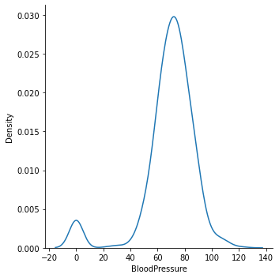

```python
#remove _____ & write the appropriate library name

sns.displot(pima['BloodPressure'], kind='kde')
plt.show()
```

#### Write your Answer here:

Ans 10: Distlpot type used in this example is kde, Kernel density estination, used to understand the density of given variable. In this example we can see most values for BloodPressure are roughly between 65 and 80 and some of the values are actually 0. Observe that we only used one variable on x axis from the dataframe and other variable on y axix is just the density representation.

## Q 11. What is the 'BMI' for the person having the highest 'Glucose'? (1 Mark)

```python
#remove _____ & write the appropriate function name
#pima['Glucose'].max()
display(pima.loc[pima['Glucose'] == 199])
pima[pima['Glucose']==pima['Glucose'].max()]['BMI']
```

|  | Pregnancies | Glucose | BloodPressure | SkinThickness | Insulin | BMI | DiabetesPedigreeFunction | Age | Outcome |
| --- | --- | --- | --- | --- | --- | --- | --- | --- | --- |
| 661 | 1 | 199 | 76 | 43 | 0 | 42.9 | 1.394 | 22 | 1 |

```
661    42.9
Name: BMI, dtype: float64
```

#### Write your Answer here:

Ans 11: We can retrieve values from a dataframe defining a matching criteria as an expression, in this case the expression is to find the max value (using max() function)in a column and use it to get another column value of the matching row.

## Q12.

### 12.1 What is the mean of the variable 'BMI'?

### 12.2 What is the median of the variable 'BMI'?

### 12.3 What is the mode of the variable 'BMI'?

### 12.4 Are the three measures of central tendency equal?

### (3 Marks)

```python
#remove _____ & write the appropriate function name

m1 = pima['BMI'].mean()  #Mean
display(m1)
m2 = pima['BMI'].median()  #Median
display(m2)
m3 = pima['BMI'].mode()[0]  #Mode
display(m3)
```

```
31.992578124999977
```

```
32.0
```

```
32.0
```

#### Write your Answer here:

Ans 12: 12.1: 31.99 or 32 rounded to the nearest integer, is the mean of BMI. 12.2: 32.0 is the median of BMI. 12.3: 32.0 is the mode of BMI. 12.4: Yes, they are the same, which also means that the data has less/no skew and the distribution is symmetric.

## Q13. How many women's 'Glucose' level is above the mean level of 'Glucose'? (1 Mark)

```
Mean of Glucose is:  120.89453125
```

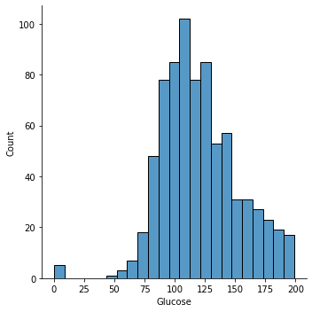

```python
#remove _____ & write the appropriate function name
print("Mean of Glucose is: ", pima['Glucose'].mean())
#pima[pima['Glucose']>pima['Glucose'].mean()].shape[0]
sns.displot(pima['Glucose'], kind='hist')
plt.show()
```

## Q14. How many women have their 'BloodPressure' equal to the median of 'BloodPressure' and their 'BMI' less than the median of 'BMI'? (2 Marks)

```python
#remove _____ & write the appropriate column name

#len(pima[(pima['BloodPressure']==pima['BloodPressure'].median()) & (pima['BMI']<pima['BMI'].median())]))

print("Median of BloodPressure:",pima['BloodPressure'].median())
print("Median of BMI:",pima['BMI'].median())

pima_q14=pima[(pima['BloodPressure']==pima['BloodPressure'].median()) & (pima['BMI']<pima['BMI'].median())]
display(pima_q14)
ans_q14 = pima_q14.shape[0]
print("Number of women with BloodPressure equal to the median of BloodPressure and their BMI less than median of BMI =",ans_q14)
```

```
Median of BloodPressure: 72.0
Median of BMI: 32.0
```

|  | Pregnancies | Glucose | BloodPressure | SkinThickness | Insulin | BMI | DiabetesPedigreeFunction | Age | Outcome |
| --- | --- | --- | --- | --- | --- | --- | --- | --- | --- |
| 14 | 5 | 166 | 72 | 19 | 175 | 25.8 | 0.587 | 51 | 1 |
| 93 | 4 | 134 | 72 | 0 | 0 | 23.8 | 0.277 | 60 | 1 |
| 103 | 1 | 81 | 72 | 18 | 40 | 26.6 | 0.283 | 24 | 0 |
| 205 | 5 | 111 | 72 | 28 | 0 | 23.9 | 0.407 | 27 | 0 |
| 299 | 8 | 112 | 72 | 0 | 0 | 23.6 | 0.840 | 58 | 0 |
| 325 | 1 | 157 | 72 | 21 | 168 | 25.6 | 0.123 | 24 | 0 |
| 330 | 8 | 118 | 72 | 19 | 0 | 23.1 | 1.476 | 46 | 0 |
| 366 | 6 | 124 | 72 | 0 | 0 | 27.6 | 0.368 | 29 | 1 |
| 380 | 1 | 107 | 72 | 30 | 82 | 30.8 | 0.821 | 24 | 0 |
| 393 | 4 | 116 | 72 | 12 | 87 | 22.1 | 0.463 | 37 | 0 |
| 406 | 4 | 115 | 72 | 0 | 0 | 28.9 | 0.376 | 46 | 1 |
| 446 | 1 | 100 | 72 | 12 | 70 | 25.3 | 0.658 | 28 | 0 |
| 460 | 9 | 120 | 72 | 22 | 56 | 20.8 | 0.733 | 48 | 0 |
| 488 | 4 | 99 | 72 | 17 | 0 | 25.6 | 0.294 | 28 | 0 |
| 497 | 2 | 81 | 72 | 15 | 76 | 30.1 | 0.547 | 25 | 0 |
| 510 | 12 | 84 | 72 | 31 | 0 | 29.7 | 0.297 | 46 | 1 |
| 568 | 4 | 154 | 72 | 29 | 126 | 31.3 | 0.338 | 37 | 0 |
| 615 | 3 | 106 | 72 | 0 | 0 | 25.8 | 0.207 | 27 | 0 |
| 635 | 13 | 104 | 72 | 0 | 0 | 31.2 | 0.465 | 38 | 1 |
| 644 | 3 | 103 | 72 | 30 | 152 | 27.6 | 0.730 | 27 | 0 |
| 717 | 10 | 94 | 72 | 18 | 0 | 23.1 | 0.595 | 56 | 0 |
| 765 | 5 | 121 | 72 | 23 | 112 | 26.2 | 0.245 | 30 | 0 |

```
Number of women with BloodPressure equal to the median of BloodPressure and their BMI less than median of BMI = 22
```

#### Write your Answer here:

Ans 14: Number of women with BloodPressure equal to the median of BloodPressure and their BMI less than median of BMI is 22.

## Q15. Create the pairplot for variables 'Glucose', 'SkinThickness' and 'DiabetesPedigreeFunction'. Write you observations from the plot. (4 Marks)

```
30.0 % of values are zeros in SkinThickness
```

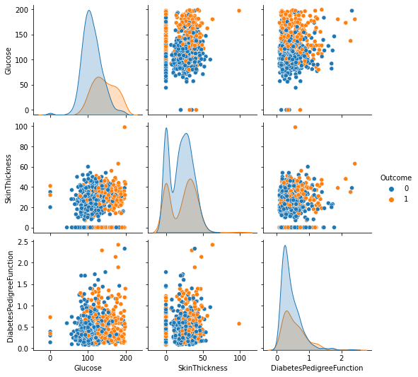

```python
#remove _____ & write the appropriate function name

print(100* ((pima['SkinThickness']==0).sum() / pima.shape[0]).round(decimals=2), "% of values are zeros in SkinThickness")
sns.pairplot(data=pima,vars=['Glucose', 'SkinThickness', 'DiabetesPedigreeFunction'], hue='Outcome')
plt.show()
```

#### Write your Answer here:

Ans 15: - About 30% of SkinThickness values are zeros, so no strong inference can be made when this variable is used. - Most diabetic women have Glucose values greater than about 120. - Most non-diabetic women have Glucose values less than about 150

## Q16. Plot the scatterplot between 'Glucose' and 'Insulin'. Write your observations from the plot. (2 Marks)

```
49.0 % of values are zeros in Insulin
```

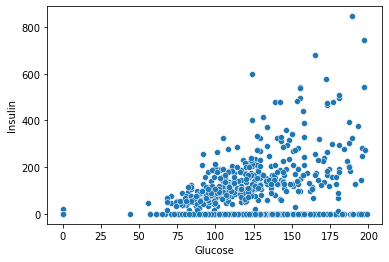

```python
#remove _____ & write the appropriate function name

print(100* ((pima['Insulin']==0).sum() / pima.shape[0]).round(decimals=2), "% of values are zeros in Insulin")
sns.scatterplot(x='Glucose',y='Insulin',data=pima)
plt.show()
```

#### Write your Answer here:

Ans 16: - About 50% of the values are zeros for Insulin, our sample may not be great. - Considering non-zero values, Glucose and Insulin are in positive linear relationship.

## Q 17. Plot the boxplot for the 'Age' variable. Are there outliers? (2 Marks)

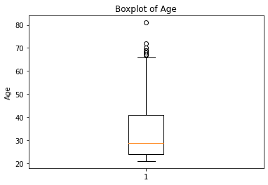

```python
#remove _____ & write the appropriate function and column name

plt.boxplot(pima['Age'])

plt.title('Boxplot of Age')
plt.ylabel('Age')
plt.show()
```

#### Write your Answer here:

Ans 17:Yes, there are outliers.

## Q18. Plot histograms for variable Age to understand the number of women in different Age groups given that they have diabetes or not. Explain both histograms and compare them. (3 Marks)

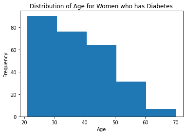

```python
#remove _____ & write the appropriate function and column name

plt.hist(pima[pima['Outcome']==1]['Age'], bins = 5)
plt.title('Distribution of Age for Women who has Diabetes')
plt.xlabel('Age')
plt.ylabel('Frequency')
plt.show()
```

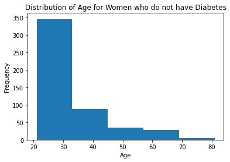

```python
#remove _____ & write the appropriate function and column name

plt.hist(pima[pima['Outcome']==0]['Age'], bins = 5)
plt.title('Distribution of Age for Women who do not have Diabetes')
plt.xlabel('Age')
plt.ylabel('Frequency')
plt.show()
```

#### Write your Answer here:

Ans 18: From first picture, women less than 50 and above 20 age seems to be more diabetic. From the second picture, most women less than 30 years are not diabetic. Comparing both, women between 30 and 45 age are more likey to be diabetic.

## Q 19. What is Inter Quartile Range of all the variables? Why is it used? Which plot visualizes the same? (2 Marks)

```python
#remove _____ & write the appropriate variable name

Q1 = pima.quantile(0.25)
Q3 = pima.quantile(0.75)
IQR = Q3 - Q1
print(IQR)
```

```
Pregnancies                   5.0000
Glucose                      41.2500
BloodPressure                18.0000
SkinThickness                32.0000
Insulin                     127.2500
BMI                           9.3000
DiabetesPedigreeFunction      0.3825
Age                          17.0000
Outcome                       1.0000
dtype: float64
```

#### Write your Answer here:

Ans 19: Boxplot is used to visualize the inter quartile range of variables.

## Q 20. Find and visualize the the correlation matrix. Write your observations from the plot. (3 Marks)

```python
#remove _____ & write the appropriate function name and run the code

corr_matrix = pima.iloc[:,0:8].corr()

corr_matrix
```

|  | Pregnancies | Glucose | BloodPressure | SkinThickness | Insulin | BMI | DiabetesPedigreeFunction | Age |
| --- | --- | --- | --- | --- | --- | --- | --- | --- |
| Pregnancies | 1.000000 | 0.129459 | 0.141282 | -0.081672 | -0.073535 | 0.017683 | -0.033523 | 0.544341 |
| Glucose | 0.129459 | 1.000000 | 0.152590 | 0.057328 | 0.331357 | 0.221071 | 0.137337 | 0.263514 |
| BloodPressure | 0.141282 | 0.152590 | 1.000000 | 0.207371 | 0.088933 | 0.281805 | 0.041265 | 0.239528 |
| SkinThickness | -0.081672 | 0.057328 | 0.207371 | 1.000000 | 0.436783 | 0.392573 | 0.183928 | -0.113970 |
| Insulin | -0.073535 | 0.331357 | 0.088933 | 0.436783 | 1.000000 | 0.197859 | 0.185071 | -0.042163 |
| BMI | 0.017683 | 0.221071 | 0.281805 | 0.392573 | 0.197859 | 1.000000 | 0.140647 | 0.036242 |
| DiabetesPedigreeFunction | -0.033523 | 0.137337 | 0.041265 | 0.183928 | 0.185071 | 0.140647 | 1.000000 | 0.033561 |
| Age | 0.544341 | 0.263514 | 0.239528 | -0.113970 | -0.042163 | 0.036242 | 0.033561 | 1.000000 |

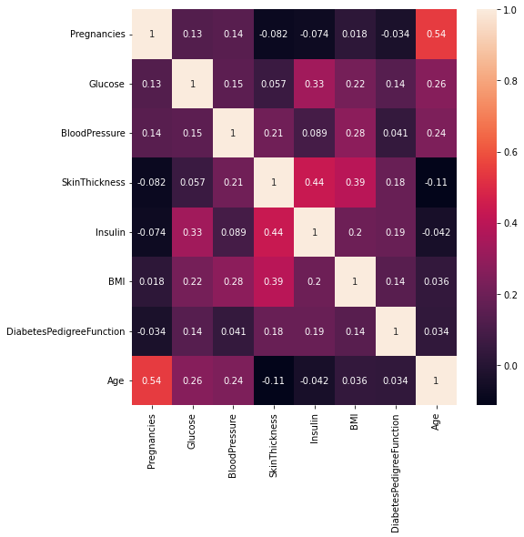

```python
#remove _____ & write the appropriate function name

plt.figure(figsize=(8,8))
sns.heatmap(corr_matrix, annot = True)

# display the plot
plt.show()
```